# Threatening Communication: Diffusing the Scientific Evidence

Gjalt-Jorn Ygram Peters, Rob A. C. Ruiter, Peter Verboon & Gerjo Kok

2017-11-10 at 17:10:30

# Descriptives & dropout

Table 1: Sample sizes at t0, t1 and t2 and sample characteristics.

|  | N_t0 | N_t1 | N_t2 | % female | age (SD) |
| --- | --- | --- | --- | --- | --- |
| **Intervention developers** | 40 | 34 | 31 | 85 | 40.3 (11) |
| **Program/campaign leaders** | 31 | 24 | 21 | 87 | 41.4 (9.2) |
| **Policy makers** | 30 | 21 | 18 | 67 | 44 (10.9) |
| **Managers** | 15 | 8 | 7 | 53 | 50.2 (11.3) |
| **Politicians** | 5 | 4 | 3 | 40 | 52.2 (7.4) |
| **Scientists** | 27 | 21 | 19 | 74 | 38.4 (8.2) |
| **Advertising professionals** | 5 | 5 | 3 | 60 | 40.2 (9.8) |
| **Total** | 153 | 117 | 102 | 75 | 42.3 (10.5) |

|  | Frequencies | Perc.Total | Perc.Valid | Cumulative |
| --- | --- | --- | --- | --- |
| **Female** | 114 | 74.5 | 74.5 | 74.5 |
| **Male** | 39 | 25.5 | 25.5 | 100 |
| **Total valid** | 153 | 100 | 100 |  |

|  | Frequencies | Perc.Total | Perc.Valid | Cumulative |
| --- | --- | --- | --- | --- |
| **Intervention developers** | 40 | 26.1 | 26.1 | 26.1 |
| **Program/campaign leaders** | 31 | 20.3 | 20.3 | 46.4 |
| **Policy makers** | 30 | 19.6 | 19.6 | 66 |
| **Managers** | 15 | 9.8 | 9.8 | 75.8 |
| **Politicians** | 5 | 3.3 | 3.3 | 79.1 |
| **Scientists** | 27 | 17.6 | 17.6 | 96.7 |
| **Advertising professionals** | 5 | 3.3 | 3.3 | 100 |
| **Total valid** | 153 | 100 | 100 |  |

Table 2: Distribution of gender.:Table 2: Distribution of role.:Table 2: Distribution of employers.

|  | Frequencies | Perc.Total | Perc.Valid | Cumulative |
| --- | --- | --- | --- | --- |
| **A national health promoting organisation** | 36 | 23.5 | 23.5 | 23.5 |
| **A regional health promoting organisation** | 38 | 24.8 | 24.8 | 48.4 |
| **A commercial organisation (e.g. advertising agency)** | 9 | 5.9 | 5.9 | 54.2 |
| **Municipal government** | 9 | 5.9 | 5.9 | 60.1 |
| **Provincial government** | 3 | 2 | 2 | 62.1 |
| **National government** | 11 | 7.2 | 7.2 | 69.3 |
| **A university** | 12 | 7.8 | 7.8 | 77.1 |
| **Other** | 35 | 22.9 | 22.9 | 100 |
| **Total valid** | 153 | 100 | 100 |  |

# Beliefs

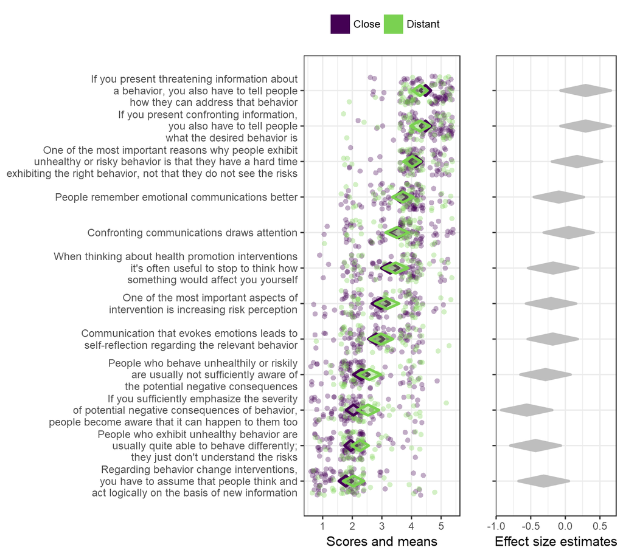

Figure 2: Participants’ beliefs regarding behavior change.

|  | lo | mean | hi | label |
| --- | --- | --- | --- | --- |
| **threateningInfoAlsoDesirableBehavior** | 4.26222 | 4.409449 | 4.556678 | If you present threatening information about a behavior, you also have to tell people how they can address that behavior |
| **ifConfrontingAlsoDesirableBehavior** | 4.245723 | 4.409449 | 4.573174 | If you present confronting information, you also have to tell people what the desired behavior is |
| **importanceOfSelfEfficacyOrSkills** | 3.932284 | 4.102362 | 4.27244 | One of the most important reasons why people exhibit unhealthy or risky behavior is that they have a hard time exhibiting the right behavior, not that they do not see the risks |
| **emotionalInfoBetterRemembered** | 3.471428 | 3.661417 | 3.851407 | People remember emotional communications better |
| **confrontingInfoDrawsAttention** | 3.309839 | 3.543307 | 3.776776 | Confronting communications draws attention |
| **usefulToConsiderOneself** | 3.102912 | 3.346457 | 3.590001 | When thinking about health promotion interventions it’s often useful to stop to think how something would affect you yourself |
| **importantToIncreaseRiskPerception** | 2.799319 | 3.03937 | 3.279421 | One of the most important aspects of intervention is increasing risk perception |
| **emotionsTriggerSelfreflection** | 2.646628 | 2.866142 | 3.085656 | Communication that evokes emotions leads to self-reflection regarding the relevant behavior |
| **insufficientAwarenessNegativeConsequence** | 2.18032 | 2.401575 | 2.62283 | People who behave unhealthily or riskily are usually not sufficiently aware of the potential negative consequences |
| **emphasisOnSeverityPersuadesSusceptibility** | 2.000477 | 2.212598 | 2.42472 | If you sufficiently emphasize the severity of potential negative consequences of behavior, people become aware that it can happen to them too |
| **behaviorChangeEasyJustRiskUnaware** | 1.890633 | 2.062992 | 2.235351 | People who exhibit unhealthy behavior are usually quite able to behave differently; they just don’t understand the risks |
| **inBehaviorChangeAssumeRationality** | 1.677889 | 1.874016 | 2.070142 | Regarding behavior change interventions, you have to assume that people think and act logically on the basis of new information |

[output not shown]

# Belief indices

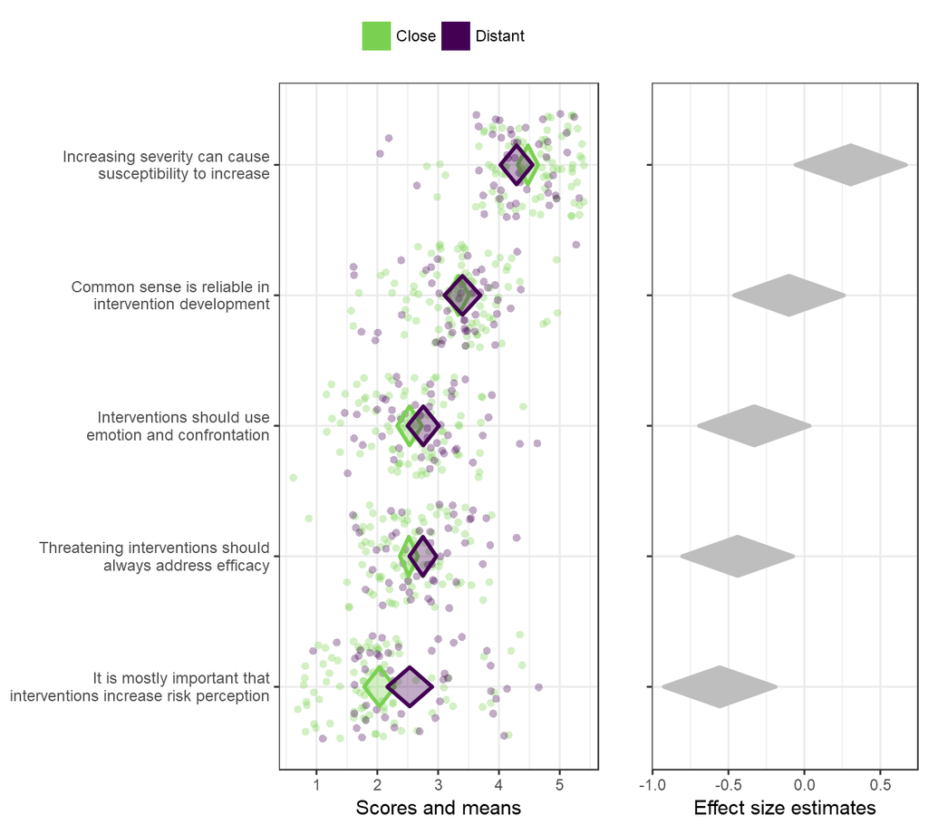

Figure 3: Participants’ belief indices regarding behavior change.

|  | lo | mean | hi | label |
| --- | --- | --- | --- | --- |
| **importanceOfSelfEfficacyOrSkills** | 3.932284 | 4.102362 | 4.27244 | One of the most important reasons why people exhibit unhealthy or risky behavior is that they have a hard time exhibiting the right behavior, not that they do not see the risks |
| **confrontingInfoDrawsAttention** | 3.309839 | 3.543307 | 3.776776 | Confronting communications draws attention |
| **emotionalInfoBetterRemembered** | 3.471428 | 3.661417 | 3.851407 | People remember emotional communications better |
| **ifConfrontingAlsoDesirableBehavior** | 4.245723 | 4.409449 | 4.573174 | If you present confronting information, you also have to tell people what the desired behavior is |
| **emotionsTriggerSelfreflection** | 2.646628 | 2.866142 | 3.085656 | Communication that evokes emotions leads to self-reflection regarding the relevant behavior |

Table 3: Associations between the belief indices and proximity to behavior change science.

|  | 1. |
| --- | --- |
| **1. threateningInterventionsShouldEnhanceEfficacy** | g=[-0.06; 0.67] |
|  | g=0.31, p=.125 |
| **2. interventionsShouldUseEmotionAndConfrontation** | g=[-0.46; 0.26] |
|  | g=-0.1, p=.585 |
| **3. commonSenseIsReliableInInterventionDevelopment** | g=[-0.69; 0.03] |
|  | g=-0.33, p=.125 |
| **4. interventionsShouldIncreaseRiskperception** | g=[-0.8; -0.07] |
|  | g=-0.44, p=.047 |
| **5. increasingSeverityIncreasesSusceptibility** | g=[-0.93; -0.19] |
|  | g=-0.56, p=.015 |

# Intervention: descriptives

## Time spent on the intervention page

Participants spent on average 7 minutes and 52.33 seconds on the page with the intervention.

## Descriptives of whether participants considered the provided intervention clear.

**Describing the central tendency:**

| mean | median | mode | 95% CI mean |
| --- | --- | --- | --- |
| 4.342 | 4 | 4 | [4.21; 4.47] |

**Describing the spread:**

| var | sd | iqr | se |
| --- | --- | --- | --- |
| 0.5293 | 0.7276 | 1 | 0.06642 |

**Describing the range:**

[output not shown]

**Describing the distribution shape:**

| skewness | kurtosis | dip |
| --- | --- | --- |
| -1.694 | 5.742 | 0.2208 |

**Describing the sample size:**

| total | NA. | valid |
| --- | --- | --- |
| 153 | 33 | 120 |

## Descriptives of whether participants indicated that they were convinced by the intervention.

**Describing the central tendency:**

| mean | median | mode | 95% CI mean |
| --- | --- | --- | --- |
| 4.167 | 4 | 5 | [4.01; 4.32] |

**Describing the spread:**

| var | sd | iqr | se |
| --- | --- | --- | --- |
| 0.7451 | 0.8632 | 1 | 0.0788 |

**Describing the range:**

[output not shown]

**Describing the distribution shape:**

| skewness | kurtosis | dip |
| --- | --- | --- |
| -0.8888 | 0.5799 | 0.1875 |

**Describing the sample size:**

| total | NA. | valid |
| --- | --- | --- |
| 153 | 33 | 120 |

# Did intervention evaluation of fear appeal interventions differ?

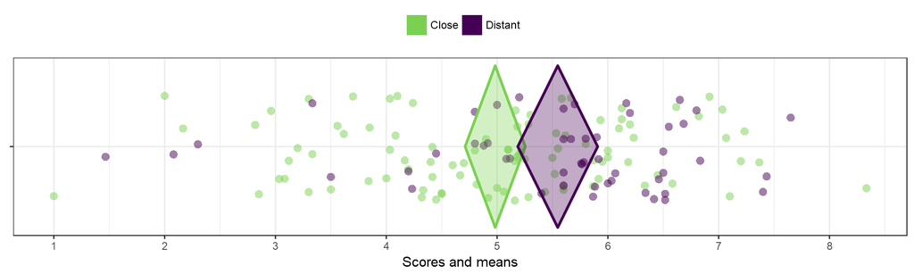

Figure 4:

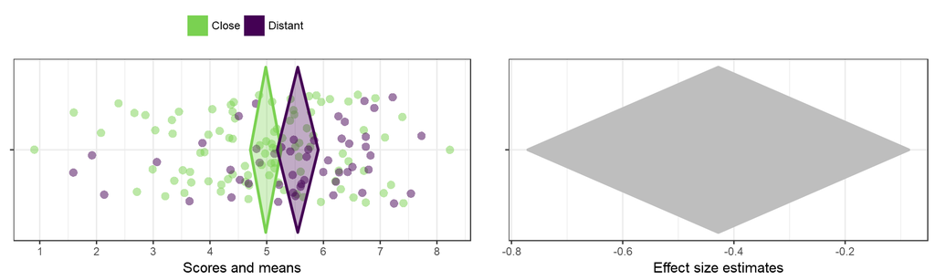

Figure 5:

**Input variables:**  
role_dichotomous (grouping variable) & t0_v1_fear_mean (dependent variable)  
Mean 1 (Close) = 4.98, sd = 1.33, n = 94  
Mean 2 (Distant) = 5.55, sd = 1.28, n = 51

**Independent samples t-test (tested for equal variances, p = .805, so equal variances)**  
(pooled standard deviation used, 1.31)

**95% confidence intervals:**  
Absolute mean difference: [-1.01, -0.11] (Absolute mean difference: -0.56)  
Cohen’s d for difference: [-0.77, -0.09] (Cohen’s d point estimate: -0.43)  
Hedges g for difference: [-0.77, -0.09] (Hedges g point estimate: -0.43)

Achieved power for d=-0.43: 0.7303 (for small: 0.2233; medium: 0.8485; large: 0.9976)

*(secondary information (NHST): t[143] = -2.47, p = .015)*

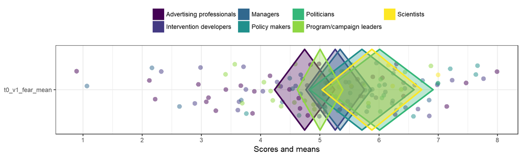

Figure 6:

# Intervention: analyses

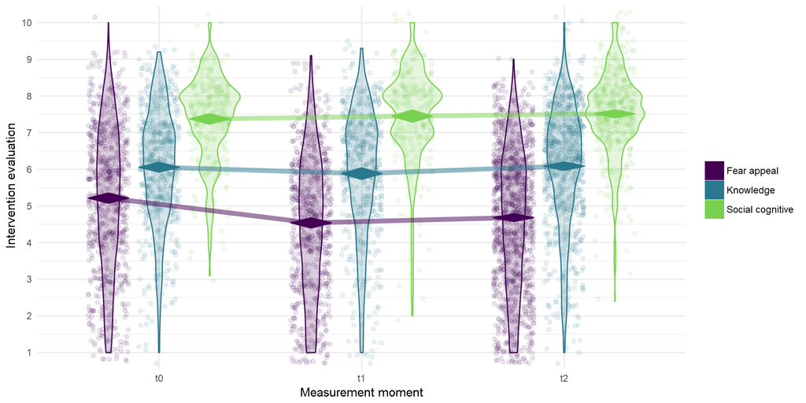

Figure 7: The evaluation of the interventions of each type over time.

```
Linear mixed model fit by REML
t-tests use  Satterthwaite approximations to degrees of freedom ['lmerMod']
Formula: value ~ measurementMoment * interventionType + numberOfScenarios +      (1 | behaviorDomain/subject)
   Data: lDat

REML criterion at convergence: 20808.7

Scaled residuals:
    Min      1Q  Median      3Q     Max
-3.4865 -0.6064  0.0691  0.6656  2.8924

Random effects:
 Groups                 Name        Variance Std.Dev.
 subject:behaviorDomain (Intercept) 0.43977  0.6632
 behaviorDomain         (Intercept) 0.05483  0.2342
 Residual                           2.42539  1.5574
Number of obs: 5411, groups:  subject:behaviorDomain, 813; behaviorDomain, 6

Fixed effects:
                                           Estimate Std. Error         df t value             Pr(>|t|)
(Intercept)                                 5.10352    0.12338   11.00000  41.364  0.00000000000015232 ***
measurementMomentt1                        -0.64929    0.08159 4772.00000  -7.958  0.00000000000000222 ***
measurementMomentt2                        -0.50057    0.07294 4903.00000  -6.863  0.00000000000757416 ***
interventionTypeknow                        0.81421    0.09025 4726.00000   9.022 < 0.0000000000000002 ***
interventionTypescd                         2.29902    0.11728 4833.00000  19.603 < 0.0000000000000002 ***
numberOfScenarios2                          0.26890    0.07445 5285.00000   3.612             0.000307 ***
numberOfScenarios3                         -0.01261    0.07498 5302.00000  -0.168             0.866469
measurementMomentt1:interventionTypeknow    0.52183    0.12857 4771.00000   4.059  0.00005014403966985 ***
measurementMomentt2:interventionTypeknow    0.56874    0.11339 4758.00000   5.016  0.00000054729680432 ***
measurementMomentt1:interventionTypescd     0.66578    0.16504 4917.00000   4.034  0.00005567550705976 ***
measurementMomentt2:interventionTypescd     0.62707    0.14513 4910.00000   4.321  0.00001586511708451 ***
---
Signif. codes:  0 '***' 0.001 '**' 0.01 '*' 0.05 '.' 0.1 ' ' 1

Correlation of Fixed Effects:
                         (Intr) msrmM1 msrmM2 intrvntnTypk intrvntnTyps nmbOS2 nmbOS3 msrmntMmntt1:ntrvntnTypk
msrmntMmnt1              -0.329
msrmntMmnt2              -0.359  0.543
intrvntnTypk             -0.202  0.422  0.476
intrvntnTyps             -0.155  0.325  0.368  0.342
nmbrOfScnr2              -0.366  0.033  0.017 -0.191       -0.070
nmbrOfScnr3              -0.365  0.033  0.016 -0.189       -0.225        0.711
msrmntMmntt1:ntrvntnTypk  0.202 -0.625 -0.336 -0.670       -0.216       -0.010 -0.011
msrmntMmntt2:ntrvntnTypk  0.227 -0.340 -0.627 -0.760       -0.244       -0.005 -0.006  0.536
msrmntMmntt1:ntrvntnTyps  0.156 -0.487 -0.261 -0.218       -0.665       -0.010 -0.003  0.324
msrmntMmntt2:ntrvntnTyps  0.177 -0.267 -0.491 -0.248       -0.753       -0.005 -0.002  0.177
                         msrmntMmntt2:ntrvntnTypk msrmntMmntt1:ntrvntnTyps
msrmntMmnt1
msrmntMmnt2
intrvntnTypk
intrvntnTyps
nmbrOfScnr2
nmbrOfScnr3
msrmntMmntt1:ntrvntnTypk
msrmntMmntt2:ntrvntnTypk
msrmntMmntt1:ntrvntnTyps  0.176
msrmntMmntt2:ntrvntnTyps  0.326                    0.540
```

# Qualitative data

These are participants’ responses to the question “Could you explain what you did not find convincing?” (“Kunt u uitleggen wat u niet overtuigend vond?”), which was asked to all participants who answered anything lower than the maximum score (“Completely”, “Volledig”) on the preceding question, “Did this information convince you?” (“Ben u door deze informatie overtuigd?”).

- Erg algemeen terwijl ik me afvraag of dit voor elk gedrag geldt en voor welke doelgroepen? Ik vraag me af of er niet verschillende methoden per doelgroep/gewenst gedrag zijn. Verder mis ik tools/methoden om de gedragsveranderingen te bereiken. Wat werkt wel en wat niet?
- De ‘wat wel te doen’ sectie lijkt enigszins eenzijdig. Ik vraag me af of het goed is om aan te raden om in principe bij gedragsveranderingsinterventies altijd een model te kiezen. Buiten het feit dat ik twijfel of er niet ook andere even goede methoden kunnen zijn in sommige gevallen, denk ik dat het voor veel interventieontwikkelaars, onderzoekers etc. moeilijk is om een goed model te kiezen waar de doelgroep zich ook daadwerkelijk mee identificeert.
- Ik denk dat emotionele boodschappen wel degelijk de aandacht trekken. Zou je ze dus niet als trigger kunnen gebruiken? Zeker bij jongeren in de puberteit waarbij de prefrontale cortex nog onvoldoende is ontwikkeld om ´verstandige´ en planmatige beslissingen te maken. Juist zij reageren vaak impulsief, kunnen we daar niet op inspelen door onze boodschap aan de buitenkant emotioneel te laden? Hebben we eenmaal hun aandacht, dan laten we de de shocherende manier van overtuigen los en gaan we over op de methode die jullie voorstellen.
- Zou bekiende auteurs of sporters niet helemaal uit willen sluiten
- Ik denk dat de effectieve interventie ook afhankelijk is van de leeftijd. Globaal de volgende te onderscheiden fasen: kinderen, pubers, jong-volwassenen, volwassenen
- Hieruit kan niet geconcludeerd worden dat emotionele of confronterende campagnes geen nut kunnen hebben binnen een breder gezondheids- (bijv. tabaks-) beleid. Binnen de (public health) populatiebenadering is het cruciaal om normen te veranderen binnen de hele populatie (niet de hoog-risico groep). De info uit de reviews is voornamelijk afkomstig uit psychologische experimenten bij indidivuen (vaak studenten) die niet gemotiveerd zijn hun gedrag te veranderen. Dan treden defensieve reacties op. Maar binnen de brede populatie zijn juist veel mensen te vinden die (in meer of mindere mate wel) open staan voor de boodschap. Bijv. bij roken is het slechts een kleine minderheid die aangeeft nooit te willen stoppen met roken. Voor de brede populatie heb je soms wel confronterende campagnes nodig om enige impact te kunnen hebben. De impact is dan vooral agenda-settend, norm veranderend (bijv. roken denormaliseren) en ondersteunend aan een bredere aanpak met regelgeving en hulpverlening. Mogelijke negatieve effecten bij een kleine groep (die er zeker zullen zijn) mogen geen reden zijn om te proberen bij de grote groep effecten te bereiken. En klein effect bij een grote groep heeft een grotere popualtie-impact dan een groot effect bij een kleine risicogroep die je intensief zou willen benaderen (wat natuurlijk vanuit individueel, psycholgoisch perspecteif atlijd te verkiezen is). Dit is een oeroude discussie binnen de public health, maar ik wil het toch nog even inbrengen, omdat ik van mening ben dat er soms te eenzijdig en zuur gedaan wordt over ‘angstaanjagende’ voorlichting. Dit heeft er deels toe geleid dat wij inmiddels in Nederland een enorme achterstand hebben ten opzichte van zo’n beetje de rest van de wereld als het gaat om collectief bewustzijn van de ernst van de schade door het roken en meeroken (zie resultaten ITC studie, ook van de UM). Camapgnes zijn taboe verklaard. Hierdoor wordt effectieve wet- en regelgeving t.a.v. tabak moeijlijker. En dat is dan weer koren op de molen van de tabaksindustrie. Er zit dus ook nog eens een politieke kant aan….
- Ik twijfel over het soort rolmodel tw acteur, sporter, artiest; ben er niet van overtuigd dat deze modellen iedereen aanspreken. Mooiste voorbeeld is Maradonna die in een anti-coke filmpje optreedt. Opteer zelf eerder voor een lid van de doelgroep die rolmodel is.
- drempels kunnen per individu sterk uiteenlopen
- Emoties zijn niet per definitie negatief en bedreigend. Geluk (zoals jullie zelf in het scenario schetsen) is ook een emotie! Ik heb daardoor met name moeite met de woordkeus. De informatie biedt in mijn ogen overigens weinig nieuws: dit wisten we toch wel?!In de tot nu toe beschreven interventies mis ik de context en het gegeven dat we in de praktijk altijd streven naar een mix van interventies: alleen een ouderavond heeft weinig zin. Er moet meer gebeuren (bv. ook iets voor de leerlingen, een website waarop ouders/leerlingen kunnen reageren). Er wordt nu teveel accent gelegd op losse elemenenten. Die zijn lastig te beoordelen zonder context.
- Sommige angstaanjagende informatie kan heel effectief zijn, als er maar een relatief simpele methode voorhanden is om de bedreiging te minimaliseren. In die zijn zijn de bevindingen te algemeen gesteld.
- Alle gegeven informatie is vooral gericht op het verstrekken van informatie aan de doelgoep. Interactie, en participatie van de doelgroep komen niet/nauwelijks aan bod. Ook wordt er iets over vaardigheden gezegd in de conclusie, terwijl dit niet voortvloeit uit de informatie.
- het ontbreken van achergronden welke achter deze informatie zit
- Dit is wel een hele lap tekst met een hoog wetenschappelijk gehalte. Lappen tekst zijn niet meer van deze tijd. Ik zou dit soort informatie via een filmpje oid aanbieden.
- Het gebruik van rolmodellen kan wel werken, als de afstand niet te groot is. Dus bv. niet George Clooney, maar Ali B. Het inroepen van experts is niet voor iedereen weggelegd, soms is dit juist een drempel. De (in te roepen)expert moet soms juist iemand ‘dichtbij huis’ zijn, dus de psycholoog op wijkniveau ipv de psycholoog in de ivoren toren.
- De noodzaak van het inschakelen van gedragsveranderingsexperts.
- Ik vroeg me af: zijn emotionele boodschappen wel effectief als ze niet bedreigend zijn? Een beroep op emoties kan wel meer betrokkenheid geven bij de boodschap?
- Ik mis ‘humor’. Wat is de rol/invloed van humor in voorlichting?
- het vermijden van “emotionele boodschappen” zou je moeten vermijden, maar dit zou ik eerder relateren aan de affectieve kant van attitude dan aan angstaanjagende boodschappen; ik zie ook niet waarom mensen zich niet met bijv. soapsterren [acteurs] zouden kunnen identificeren, daarop zijn soaps toch juist gericht?
- Nieuw onderzoek is het beste wat we weten op dit moment.Maar er zal nieuw onderzoek komen dat dit tegenspreekt of toch nog op een andere manier kijkt naar het geven van informatie rondom gedragsverandering.
- Herhaling.Misvatting over de term: emotionele boodschap. Ik had deze positief opgevat, maar denk nu dat de auteur bedoeld dat het een bop0dschap is die negatieve emotionele reactie oproept.
- Zoals in het bovenstaande verhaal is aangegeven klopten verschillende veronderstellingen in het kader van gedragsinterventies in het verleden niet (e.g. angstaanjagende booschappen zijn effectief). Boven staan nieuwe inzichten gebaseerd op wetenschappelijk onderzoek. Ik ben daarom bijna helemaal ervan overtuigd dat ze meer kloppen dan de eerdere veronderstellingen. Echter, zelfs deze nieuwe inzichten zullen op bepaalde wijzen (uiteindelijk blijken) niet (te) kloppen. Ik zou dus niet aangeven dat ik “volledig” overtuigd ben.
- Gegevens zijn interpretaties van onderzoeken. Lastig te checken. Ik zou de onderzoeken zelf willen zien.
- Er wordt volledig voorbij gegaan aan bepaalde aspecten, zoals de verkrijgbaarheid van bepaalde producten, de invloed van marketing, de prijs van bepaalde producten, de verslavende eigenschappen van bijvoorbeeld sigaretten, alcohol, vet en suiker en het inzetten van andere omgevingsfactoren, zoals fiscale maatregelen om gewenst gedrag te stimuleren of juist te ontmoedigen. Dit veronderstelt dat gedrag wordt vertoond in een vacuum, terwijl juist alle hierboven genoemde factoren direct van invloed zijn op gedrag.
- Ik geloof wel dat de rolmodellen-aanpak kan werken. maar niet altijd en niet per definitie. bovendien andere aanpakken -die hier niet aan de orde zijn geweest- zouden ook prima kunnen werken.
- Het is een lap tekst waar ik niet zo goed doorheen kom.
- Ik zou nog graag onderbouwing vanuit de theorie van de logische niveaus zien
- Angstaanjagende methode werkt zo goed als nooit wordt gezegd. Ok. Als je echter via ouders wilt bereiken dat zij jongeren op een gezondheidsthema als alcohol en roken goed opvoeden, kan duidelijkheid over gevolgen voor longen en hersenen etc wel helpen. Sommigen noemen dit de angstaanjagende benadering, en ik ben er niet van overtuigd dat dit niet goed zou werken, om aandacht te krijgen voor het probleem. En als je daarnaast opvoedondersteuning biedt. Maar anderen noemen dit objectieve informatie, kennisoverdracht. Dan kom ik er niet helemaal meer uit.
- De variabelen die nodig zijn om maatwerk te maken in diverse situaties.
- IK ben het met veel punten al eens maar heb mijn bedenkingen bij een onderdeel van wat “Wel te doen”. Mijn ervaring is dat het werken met rolmodellen, zoals bekende sporters bij het sportactiever krijgen van leerlingen zeer goed werkt, mits ze inderdaad nog redelijk dicht bij de doelgroep staan. Maar het mogen wel degelijk mensen zijn waar tegenop wordt gekeken. Ik denk ook dat een aantal punten afhangt van de doelgroep waar je mee te maken hebt. Dit gold overigens ook voor de vragen die in het vorige deel werden gesteld. Verder betreft bedreigende interventies. Ook hier ben ik het met het onderzoek eens, maar met nuance. Het blijkt ook uit interventies bij verslavingsprobleamtiek dat een bedreigende interventie (in omgekeerde versie: namelijk welke positieve gevolgen gedragsverandering kan hebben) helpend kan zijn als iemand al besloten heeft zijn gedrag te veranderen.Het helpt dan dit gedrag te continueren. En als laatste betreft de vorige stellingen waar ik op kon antwoorden vond ik de keuze voor de 5 opties niet altijd passend. Bijvoorbeeld bij de stelling : Communicatie die emoties opwekt leidt tot zelfreflectie…… Of dat zo is hangt naar mijn idee helemaal van het soort emotie af en van de persoon in kwestie en of het op het goede moment is. Het kan bij iemand net de juiste snaar raken, maar hoeft ook helemaal niet. Emotie kan helpen maar kan ook weer tegengesteld werken. De optie Ik weet niet lees ik dan als: soms wel soms niet
- Ik denk dat het soms van de doelgroep afhankelijk is wat voor een modellen ‘aanslaan’ bij de doelgroep. Ik ben het er mee eens dat mensen zich niet identificeren met een bekende acteur, maar hij/zij kan wel een extra stimulans teweeg brengen, naar mijn mening.
- Mss heb ik te snel gelezen omdat dit onderzoek weliswaar heel leuk is maar ook meer tijd kost dan ik dacht. In elk geval mis ik twee dingen: 1. dacht dat voor een korte termijn gedragsverandering een confrontatie techniek wel zinvol kan zijn (vuurwerk, pandemie) 2. ik mis (communicatie over) het veranderen van omgevingsfactoren als belangrijk hulpmiddel/aanjager voor gedragsverandering.
- het aspect van de training van vaardigheden is erg belangrijk. Maar hoe zit het met de relatie tussen vaardigheden en drijfveren van de personen die nog niet vaardig genoeg zijn? Moet het rolmodel herkenbare vergelijkbare drijfveren en waarden laten zien?
- Het gaat ten dele in tegen onderzoek van Maddux en Rogers en het Extended Parallel Process Model van Witte. Hieruit komt naar voren dat fear appeals effectief zijn als er 4 componenten aanwezig zijn, hier zijn perceived severity en perceived vulnerability er 2 van. Ik vraag mij af: als je mensen niet duidelijk maakt wat de risico’s zijn en dat zij zelf risico lopen, ontstaat er dan wel motivation to act?? Mijn (huidige) mening is dat de 4 componenten allen aanwezig moeten zijn: perceived severity, perceived vulnerability, response efficacy en self-efficacy. Maar ik ben erg benieuwd naar jullie onderzoek, zou daar graag meer over lezen en sta erg open voor jullie resultaten!
- emotionele boodschappen die positief zijn kunnen wel effectief zijn
- Info is overtuigend. Ik werk zelf veel in onderwijs of trainingssettingen, waarbij de rol van de docent of trainer een hele belangrijke is. De ‘toon’ waarop is mijnsinziens ook erg belangrijk en het ‘belerende vingertje’ (is ook een vorm van shockeren volgens mij) proberen achterwege te laten. In het ‘belerende vingertje’ zit altijd/vaak een ‘je bent ook dom’ boodschap. Ik maak veel gebruik van het i-change model om de modules en interventies op de baseren, gekoppeld aan afwisselende werkvormen (kennis, filmmateriaal, werkopdrachten, discussie etc).
- Ik heb nog geen half a4 gelezen over een onderwerp waar ik geen verstand van heb en de links niet bestudeerd. De conclusie komt redelijk overeen met mijn eigen beeld, dus ben ik redelijk overtuigd. Om volledig overtuigd te zijn, zou ik mij aanmerkelijk meer in de materie moeten verdiepen. Ik vind redelijk al best goed, eigenlijk…
- ik denk dat het uitgangspunt van de doelgroep (wat denken zij dat hen wel of niet aanzet (of tegenhoudt) tot het gezonde gedrag) hierin ook moet worden meegenomen. Het klinkt nu alsof de professional weet wat wel of niet gaat werken. Dit moet mijns inziens worden gecheckt bij de doelgroep.
- ik houd graag een slag om de arm!
- Het is mijn inziens ook afhankelijk van het doel wat je wilt bereiken met de interventie. Ik ga met het verhaal mee als het doel gedragsverandering is. maar als het sec bewustwording is, kan ik me voorstellen dat angstaanjagende boodschappen een functie kan hebben. Sowieso geloof ik niet in 1 benadering (1 size fits) maar in verschillende soorten benaderingen. Sommige mensen zullen zich absoluut niet aangesproken voelen met een angstaanjagende boodschap, anderen wel. In elk geval kan het helpen om een discussie op gang te brengen. Ik denk dus dat angstaanjagende boodschappen wel zeker een functie kunnen hebben… het hangt er dus van af wat je doel is.
- Ik heb (natuurlijk) op dit moment niet alle studies tot mij genomen die in de linkjes zitten. Deze interventies kunnen werken, maar er zullen ook mensen zijn die daar aversie tegen hebben, bijvoorbeeld doordat ze een opvoeding hebben gehad die al op deze manier werkte en waar ze niet gelukkig van werden (een moeder die op deze manier te werk gaat kan in de puberteit enorm veel irritatie opwekken, dan is de peergroup veel interessanter)
- Ik vraag me af of je helemaal niet moet refereren aan de risico’s, er is een verschil tussen het relevant maken van de risico;s van het gedrag en de risico’s enorm hoog opspelen.
- punt 4 nog wat te veel woorden
- Over die bekende mensen, rolmodellen, zoals sporters e.d. Dat lijkt me wel een goede manier, omdat jongeren graag net zo als deze mensen willen zijn. Voorbeelden, niet drinken van alcohol in soaps.
- Telkens blijft naar voren komen dat mensen iets niet goed doen en dat iemand wel even zal voordoen hoe het moet. Dat zijn per definitie ‘jeuksituaties’. Het woord ‘model’ geeft al aan dat het geen echte persoon is, toch?
- In de samenvatting punt 3. ‘vaardigheden en waargenomen vaardigheden van de doelgroep’; dat waargenomen is niet duidelijk en in mijn ogen door het voorgaande niet afdoende onderbouwd. Daarnaast wordt geadviseerd om gebruik te maken van rolmodellen die vaardigheden voordoen. Akkoord, maar hoe verhoudt zich dat tot de actieve leervormen die net daarvoor zijn voorgesteld?
- heb achtergrondstudies niet kunnen beoordelen, that’s all
- De informatie gaat vooral over de voorbeeldfunctie die de modellen hebben, de voorlichtingsfunctie. Bij interventie hoort m.i. ook coaching van de doelgroep in het uitvoeren van het gewenste gedrag.
- deel van de informatie was al bij mij bekend, daar hoef ik dus niet meer voor overtuigd te worden, dat was ik al.
- In de informatie/conclusies wordt geen link gelegd met de achtergrondkenmerken van de doelgroep. Ik kan mij niet voorstellen dat deze conclusies op alle bevolkingsgroepen van toepassing zijn. Bijvoorbeeld onderscheid naar opleiding ligt erg voor de hand.
- ik heb de referenties nog niet gecheckt
- Ik ben wel overtuigd door de informatie, maar ben niet overtuigd dat dit de enige oplossing is.
- Ik ben het minst overtuigd van het inzetten van rolmodellen als meest voor de hand liggend middel; zéker als dit wordt ingezet als het enige middel (en in de tekst wordt niet over andere aanvullende middelen gesproken).
- Ik ben van mening dat confrontatie zo af en toe nodig is om mensen bewust te maken van de risico’s die zij lopen als ze het huidige gedrag aanhouden. Ik coach mensen bij voeding en gedragsverandering en daarbij pas ik confrontatie ook wel eens toe. Risicocommunicatie is belangrijk, en in eerste instantie zou ik dit ook zo feitelijk mogelijk over willen brengen, maar als het niet goed doordringt zou ik eerder proberen mensen te confronteren zodat het wel doordringt.
- Wat je dacht is dus niet juist. dus dat is even je gedachten omzetten en dat heeft tijd nodig.
- Ik denk dat je in een soapserie best een bovenstaand scenario toe kunt passen (en dat is wel een bekende acteur) wat effect heeft.
- De manier hoe de informatieoverdracht is opgebouw; verwijzen naar recente literatuur, interviews en resulaten. Met daarna korte samenvatting en hoe men het beste te werk zou kunnen gaan.
- communicatie op een neutrale en feitelijke manier is vaak te saai om mensen aan te spreken nmm zijn er toch altijd beelden nodig
- Wat je misschien beter kunt doen is niet een model meenemen maar iemand uit de doelgroep zelf zijn/haar situatie laten vertellen en dan met de groep nadenken wat het gewenste reacties/gedrag zou zijn, en dit vervolgens met die persoon naspelen. Zo train je de groep zelf in bedenken van effectief gedrag en oefen je gelijk de vaardigheden met de doelgroep.
- De informatie staat er vrij stellig. Ik kan me voorstellen dat het soms genuanceerder is. Bijv gebruik van rolmodellen..en hierbij geen gebruik te maken van acteurs. Voor een bepaalde doelgroep kan dit volgens mij wel werken